# Linear Model of Automotive Price

Ricardo S. Carvalho

August 1st, 2016

## Summary and conclusions

This document is intended to be a concise report to explain the evaluation of a linear model of automotive price on a dataset containing information about cars (available [here](https://raw.githubusercontent.com/StephenElston/DataScience350/master/Lecture1/Automobile%20price%20data%20_Raw_.csv)). The analysis was created as part of the **Data Science Certificate** in the class **Methods for Data Analysis** at **University of Washington**.

The idea is to show some findings regarding the significance and perfomance of a linear model of automotive price created using the continuous varibles engine.size, curb.weight and city.mpg. The function created to load the data is included in the appendix.

## Loading the data

This report considers data pre-processing as described by “[Analysis of Categorical Variables of Auto Data Report](http://rpubs.com/ricardosc/auto-categorical-variables)”.

```r
## read.auto function loads and cleans the data
Auto.Price = read.auto(path = '.') # function read.auto is included in the appendix
```

## Linear Modeling

Following we create the linear regression model of (log of) price by the continuous variables engine.size, curb.weight and city.mpg.

```r
## Creates linear model
lm.auto = lm(lnprice ~ engine.size + curb.weight + city.mpg, data = Auto.Price)
```

## Significance Evaluation of the Model

To evaluate the significance of the linear model coefficients we use the model summary.

```r
## Model summary
summary(lm.auto)
```

```
##
## Call:
## lm(formula = lnprice ~ engine.size + curb.weight + city.mpg,
##     data = Auto.Price)
##
## Residuals:
##      Min       1Q   Median       3Q      Max
## -0.45071 -0.12925 -0.01462  0.10200  0.69665
##
## Coefficients:
##               Estimate Std. Error t value Pr(>|t|)
## (Intercept)  8.1831862  0.1826404  44.805  < 2e-16 ***
## engine.size  0.0030205  0.0006566   4.600 7.54e-06 ***
## curb.weight  0.0004881  0.0000605   8.068 6.87e-14 ***
## city.mpg    -0.0184191  0.0033892  -5.435 1.61e-07 ***
## ---
## Signif. codes:  0 '***' 0.001 '**' 0.01 '*' 0.05 '.' 0.1 ' ' 1
##
## Residual standard error: 0.2036 on 197 degrees of freedom
##   (4 observations deleted due to missingness)
## Multiple R-squared:  0.8381, Adjusted R-squared:  0.8356
## F-statistic: 339.9 on 3 and 197 DF,  p-value: < 2.2e-16
```

We can see from the summary that all three coefficients have a very small p-value for the hypothesis tests with null hypothesis that they are zero. Therefore, rejecting the null hypothesis, we see that all the variables used in the linear model are significant.

Another useful test is shown in the end of the summary: F-statistic. The null hypothesis is that none of the variables used is significant. With a very small p-value, we can also reject the null hypothesis, confirming the coefficients significance.

## Performance of the Model

From the model summary above, we see that the model fit has satisfactory performance. It resulted in Adjusted R-squared of 0.8356, which shows that the model explains approximately 84% of the variation in the data.

Diagnostic plots can also be used to evaluate the performance of the model fit.

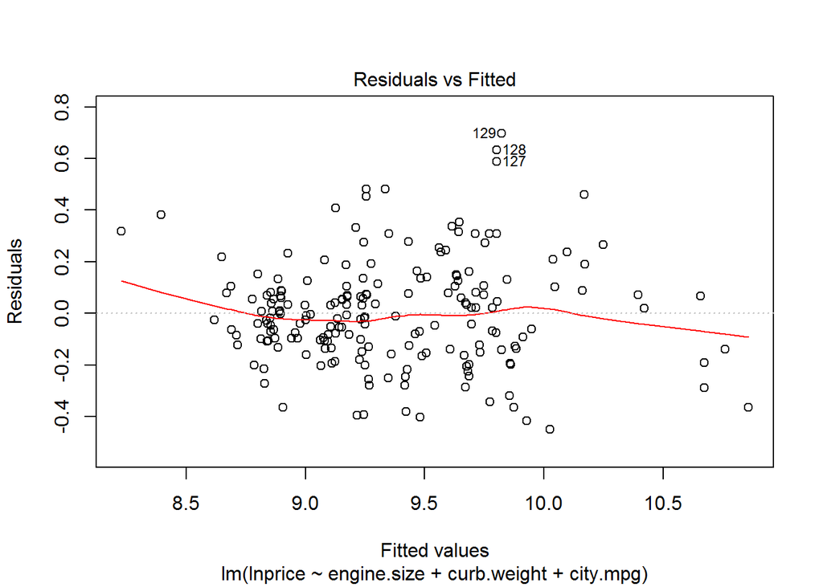

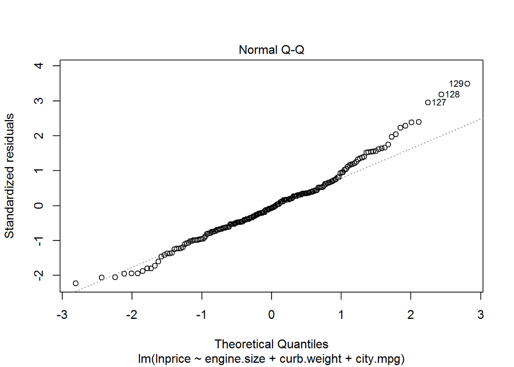

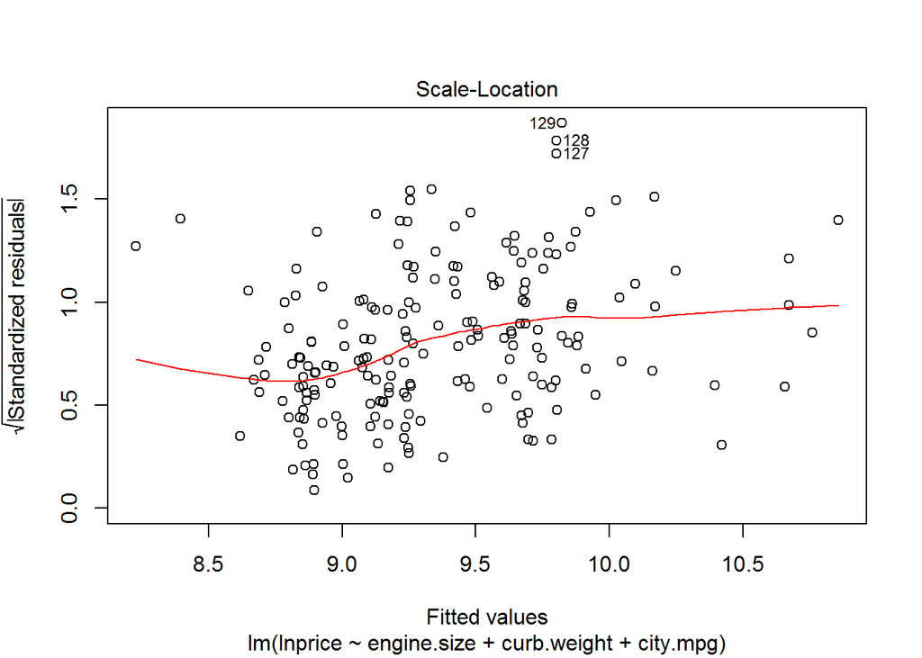

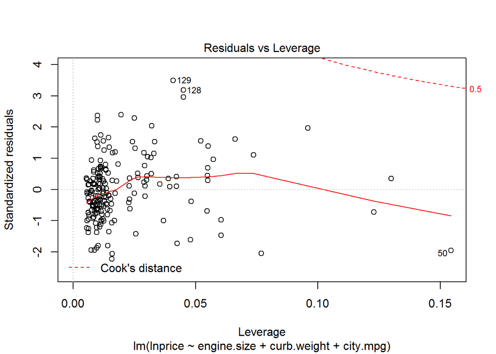

```r
## Diagnostic plots
plot(lm.auto)
```

The fourth plot shows standardized residuals by leverage, also displaying Cook’s distance. From this plot we can see that a few outliers exist and might be a good practice removing them, such as rows 50, 128 and 129.

The second diagnostic plot shows a Q-Q Plot of the standardized residuals. Since the points are close to the dotted line, we can assume a behaviour close to normality for the residuals.

To confirm the normality of the residuals we do a Shapiro-Wilk normality test.

```r
## Shapiro-Wilk normality test
shapiro.test(residuals(lm.auto))
```

```
##
##  Shapiro-Wilk normality test
##
## data:  residuals(lm.auto)
## W = 0.9787, p-value = 0.003781
```

Contrary to the Q-Q Plot, the Shapiro-Wilk test does not confirm the normality of the residuals, since that with a very small p-value we reject the null hypothesis that the residuals come from a normal distribution. This may not completely invalidate the assumption, since it may need more data to confirm normality using this test.

## Appendix

Function used in this report is showed below.

```r
##  Read the csv file into a data frame
read.auto <- function(path = 'SET-YOUR-PATH-HERE'){
    ## Function to read the csv file
    filePath <- file.path(path, 'Automobile price data _Raw_.csv')
    auto.price <- read.csv(filePath, header = TRUE,
                           stringsAsFactors = TRUE, na.strings = "?")

    ## Coerce some character columns to numeric
    numcols <- c('price', 'bore', 'stroke', 'horsepower', 'peak.rpm',
                 'highway.mpg', 'city.mpg', 'compression.ratio',
                 'engine.size', 'curb.weight', 'height', 'width',
                 'length', 'wheel.base', 'normalized.losses',
                 'symboling')
    auto.price[, numcols] <- lapply(auto.price[, numcols], as.numeric)

    ## Clean and tidy num.of.doors
    auto.price$num.of.doors <- as.character(auto.price$num.of.doors)
    auto.price$num.of.doors[auto.price$num.of.doors == 'four'] <- 4
    auto.price$num.of.doors[auto.price$num.of.doors == 'two'] <- 2
    auto.price$num.of.doors <- as.integer(auto.price$num.of.doors)

    ## Since the only NAs in num.of.doors are of cars with body.style sedan, they have 4 doors
    auto.price$num.of.doors[is.na(auto.price$num.of.doors)] <- 4

    ## Clean and tidy num.of.cylinders
    auto.price$num.of.cylinders <- as.character(auto.price$num.of.cylinders)
    auto.price$num.of.cylinders[auto.price$num.of.cylinders == 'eight'] <- 8
    auto.price$num.of.cylinders[auto.price$num.of.cylinders == 'five'] <- 5
    auto.price$num.of.cylinders[auto.price$num.of.cylinders == 'four'] <- 4
    auto.price$num.of.cylinders[auto.price$num.of.cylinders == 'six'] <- 6
    auto.price$num.of.cylinders[auto.price$num.of.cylinders == 'three'] <- 3
    auto.price$num.of.cylinders[auto.price$num.of.cylinders == 'twelve'] <- 12
    auto.price$num.of.cylinders[auto.price$num.of.cylinders == 'two'] <- 2
    auto.price$num.of.cylinders <- as.integer(auto.price$num.of.cylinders)

    auto.price$lnprice <- log(auto.price$price)

    auto.price
}
```